# HW6

2022-11-28

```r
library(tidymodels)
library(ISLR)
library(ISLR2)
library(tidyverse)
library(dplyr)
library(ggplot2)
library(glmnet)
library(klaR)
library(corrr)
library(corrplot)
library(discrim)
library(poissonreg)
library(rpart.plot)
library(vip)
library(randomForest)
library(ranger)
library(janitor) #loading the janitor package
library(xgboost)
library(data.table)
tidymodels_prefer()
pokemon <- read_csv(file='/Users/weiqizhai/Desktop/Pokemon.csv')
```

Q1:

```r
pokemon <- clean_names(pokemon)
pokemon1<-pokemon %>% filter(pokemon$type_1==c("Bug","Fire","Grass","Normal","Water","Psychic"))
pokemon1$type_1 <- factor(pokemon1$type_1)
pokemon1$legendary <- factor(pokemon1$legendary)

set.seed(2022)
pokemon_split<- initial_split(pokemon1, prop=0.7,strata=type_1)
train_set <- training(pokemon_split)
test_set <- testing(pokemon_split)

pm_fold <- vfold_cv(train_set, v = 5, strata=type_1)

pokemon_recipe <- recipe(type_1 ~ legendary+generation+sp_atk+attack+speed+
                           defense+hp+sp_def, train_set)%>%
  step_dummy(legendary,generation)%>%
  step_normalize(all_predictors())
```

Q2:

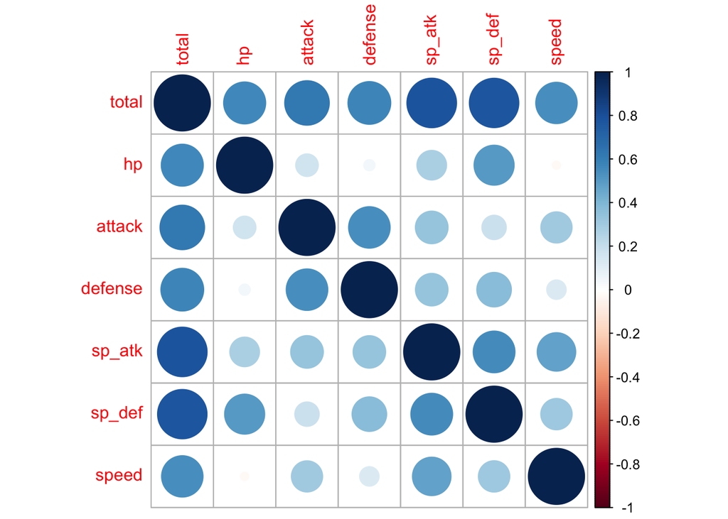

```r
train_set %>% select(is.numeric,-generation,-number) %>%
  cor() %>%
  corrplot()
```

The correlation matrix contains only numeric variables (variables of other types have been excluded from the plot), and “number” has also been excluded from the plot. From the plot, all variables are positively correlated with one another, with the exception of speed and hp(horsepower), which are negatively correlated.

Q3:

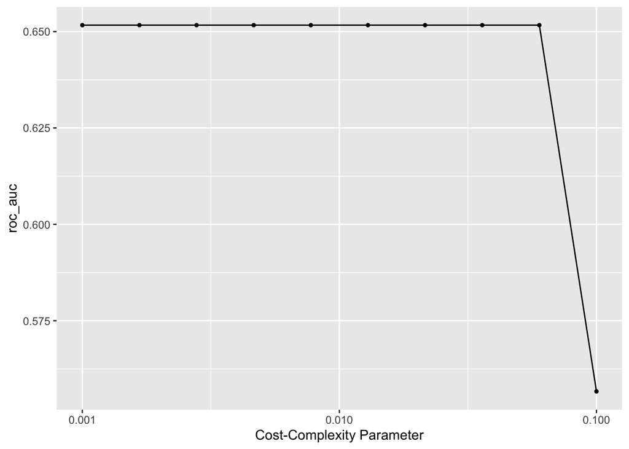

```r
tree_spec <- decision_tree() %>% set_engine('rpart')
pm_tree_spec <- tree_spec %>% set_mode("classification")
pm_tree_fit <- pm_tree_spec %>% fit(type_1~legendary+generation+sp_atk+attack+speed+
                           defense+hp+sp_def, data=train_set)

pm_wf <- workflow() %>% add_model(pm_tree_spec%>% set_args(cost_complexity = tune())) %>%
  add_formula(type_1 ~ legendary +generation + sp_atk +attack +speed + defense +hp + sp_def)
pm_grid <- grid_regular(cost_complexity(range = c(-3, -1)), levels = 10)
pm_tune_res <- tune_grid(
  pm_wf,
  resamples = pm_fold,
  grid = pm_grid,
  metrics = metric_set(roc_auc)
)
autoplot(pm_tune_res)
```

I’ve observed that roc_auc remains constant until the complexity penalty reaches a certain value; after this value, roc_auc begins to decrease and continues to decrease for the remainder of the complexity penalty value. Hence we can conclude that a single decision tree perform better with a smaller complexity penalty.

Q4:

```r
best_complexity<-select_best(pm_tune_res)
collect_metrics(pm_tune_res)
```

```
## # A tibble: 10 × 7
##    cost_complexity .metric .estimator  mean     n std_err .config
##              <dbl> <chr>   <chr>      <dbl> <int>   <dbl> <chr>
##  1         0.001   roc_auc hand_till  0.652     5  0.0465 Preprocessor1_Model01
##  2         0.00167 roc_auc hand_till  0.652     5  0.0465 Preprocessor1_Model02
##  3         0.00278 roc_auc hand_till  0.652     5  0.0465 Preprocessor1_Model03
##  4         0.00464 roc_auc hand_till  0.652     5  0.0465 Preprocessor1_Model04
##  5         0.00774 roc_auc hand_till  0.652     5  0.0465 Preprocessor1_Model05
##  6         0.0129  roc_auc hand_till  0.652     5  0.0465 Preprocessor1_Model06
##  7         0.0215  roc_auc hand_till  0.652     5  0.0465 Preprocessor1_Model07
##  8         0.0359  roc_auc hand_till  0.652     5  0.0465 Preprocessor1_Model08
##  9         0.0599  roc_auc hand_till  0.652     5  0.0465 Preprocessor1_Model09
## 10         0.1     roc_auc hand_till  0.557     5  0.0314 Preprocessor1_Model10
```

The roc_auc of the best-performing pruned decision tree on the folds is 0.65

Q5:

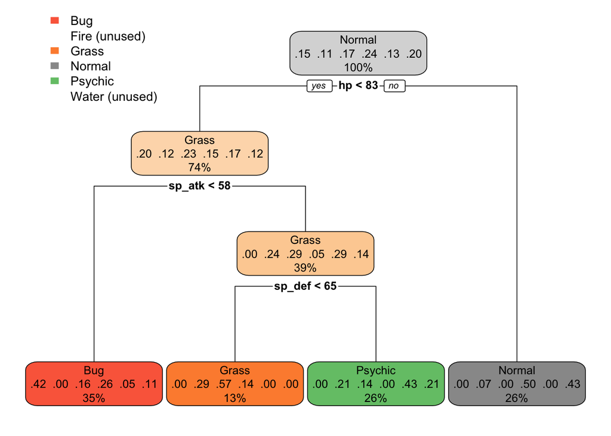

```r
pm_tree_final <- finalize_workflow(pm_wf, best_complexity)
pm_tree_final_fit <- fit(pm_tree_final, data = train_set)
pm_tree_final_fit %>%
  extract_fit_engine() %>%
  rpart.plot()
```

```r
rf_spec <- rand_forest(mtry = tune(),trees=tune(), min_n=tune()) %>%
  set_engine("ranger", importance = "impurity") %>%
  set_mode("classification")

rf_wf <- workflow() %>% add_model(rf_spec) %>%
  add_recipe(pokemon_recipe)
rf_grid <- grid_regular(mtry(range = c(1, 8)),
                             min_n(range=c(2,8)),
                                   trees(range=c(8,450)), levels = 8)
```

mtry, which represents the number of predictors at each split, should not exceed the total number of predictors. mtry is a restriction that forces each split to consider only a subset of the predictors (de-correlating the trees), thereby preventing every tree from splitting on the same predictor, thereby reducing the variance and the overall test error. When m is less than one, each tree has no predictor variable to split on at the initial split, which is invalid. In this case, t he number of predictor variables is eight, so the maximum value of m should not exceed eight. mtry=8 represents a bagged model.

Q6:

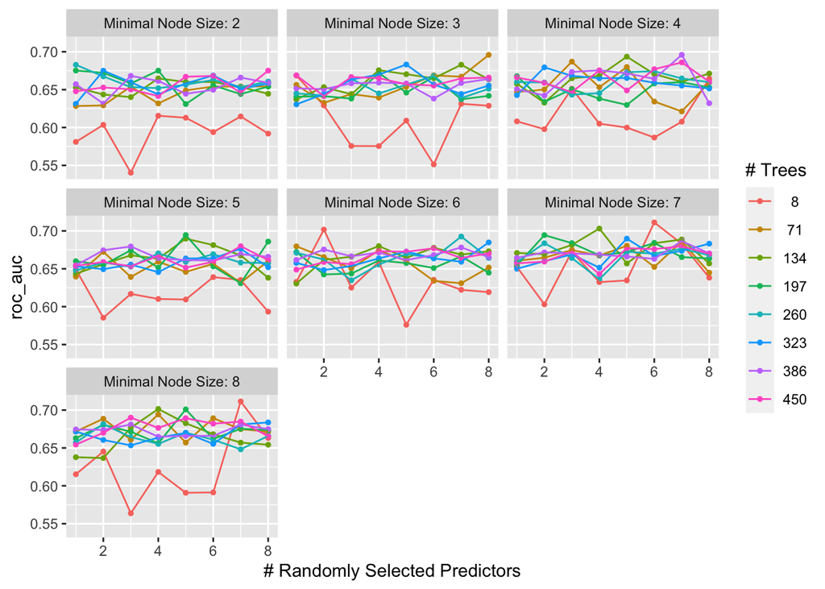

```r
rf_tune_res <- tune_grid(
  rf_wf,
  resamples = pm_fold,
  grid = rf_grid,
  metrics = metric_set(roc_auc)
)
autoplot(rf_tune_res)
```

Q7:

```r
best_hp<-select_best(rf_tune_res)
collect_metrics(rf_tune_res)
```

```
## # A tibble: 448 × 9
##     mtry trees min_n .metric .estimator  mean     n std_err .config
##    <int> <int> <int> <chr>   <chr>      <dbl> <int>   <dbl> <chr>
##  1     1     8     2 roc_auc hand_till  0.581     5  0.0671 Preprocessor1_Model…
##  2     2     8     2 roc_auc hand_till  0.604     5  0.0448 Preprocessor1_Model…
##  3     3     8     2 roc_auc hand_till  0.540     5  0.0534 Preprocessor1_Model…
##  4     4     8     2 roc_auc hand_till  0.616     5  0.0112 Preprocessor1_Model…
##  5     5     8     2 roc_auc hand_till  0.613     5  0.0226 Preprocessor1_Model…
##  6     6     8     2 roc_auc hand_till  0.594     5  0.0340 Preprocessor1_Model…
##  7     7     8     2 roc_auc hand_till  0.615     5  0.0270 Preprocessor1_Model…
##  8     8     8     2 roc_auc hand_till  0.592     5  0.0537 Preprocessor1_Model…
##  9     1     8     3 roc_auc hand_till  0.669     5  0.0230 Preprocessor1_Model…
## 10     2     8     3 roc_auc hand_till  0.629     5  0.0373 Preprocessor1_Model…
## # … with 438 more rows
```

Q8:

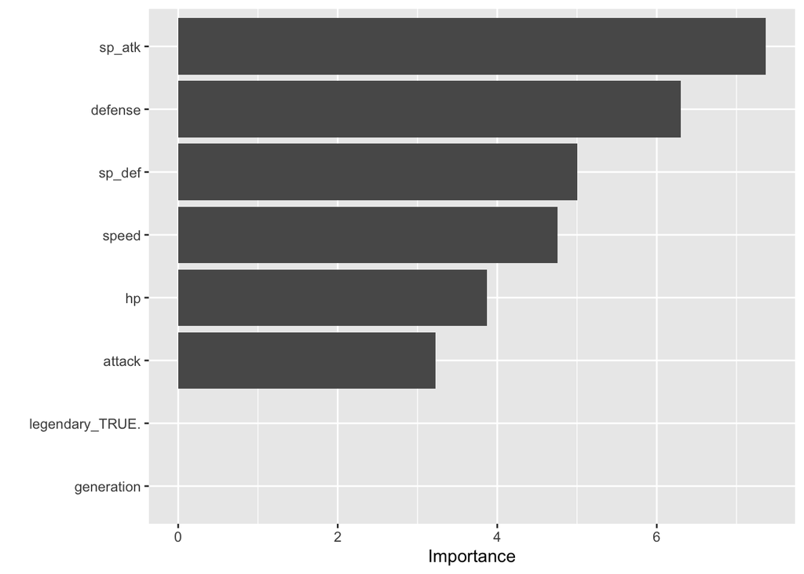

```r
rf_tree_final <- finalize_workflow(rf_wf, best_hp)
rf_tree_final_fit <- fit(rf_tree_final, data = train_set)
vip(extract_fit_engine(rf_tree_final_fit))
```

sp_atk is most useful; legendary_TRUE and generation are least useful. These results are what I expected.